# **Economic Decline and Climate Trade-Offs:** Voter Behavior and Green Party Dynamics

EPSA 2024, July 4-6, Cologne

Frederik  
Thieme

frederik.thieme@hu-berlin.de

Humboldt-Universität zu Berlin

July 2, 2024

# Puzzle 🧩

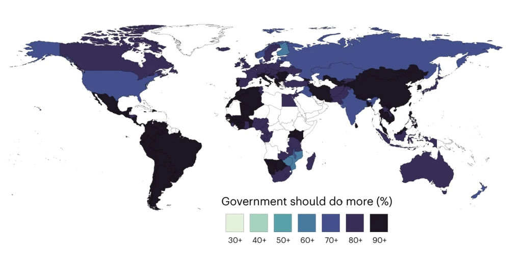

Global support for climate action. Plot by Andre et al. (2024)

# Overview

- ❓ `Question`: Do people de-prioritize climate protection and green parties when experiencing personal economic decline?
- 💡 `Argument`: Material trump non-material concerns, this travels to party preferences
- ️⚙️ `Data & Method`: GLES panel (Germany), DiD-Design
- 📊 `Results`: after experiencing economic decline, voters…
  - prioritize economic growth over climate protection
  - decrease their preference for the Greens

# Contribution

- green party success under economic **prosperity vs. recession** (Abou-Chadi and Kayser 2017; Gourley and Khamis 2023)
- **economic decline/hardship** and (green) political attitudes (Kurer and Van Staalduinen 2022; Schaub 2021; Rudolph and Gomm 2024)
- `Question`: What is the **micro-level mechanism** for green preferences?

# Expectations

Following postmaterial theory (Inglehart 1971, 2008) and previous literature:

- **H1**: The experience of downward economic mobility causes people to `prioritize economic growth` over climate protection.
- **H2**: The experience of downward economic mobility causes a `decreased preference for green parties`.

# Long-term analysis

## Data & Design

- panel data from Germany, **GLES** (2016-2023), **N = 37,000**
- `predictor`: change in assessment of **personal financial situation**
- `outcomes`:
  - **trade-off** between climate protection vs. economic growth
  - preference of the German **Greens**
- `estimation`: association between downward experience (quasi-treatment) and outcomes

## Results I

Climate vs. growth `trade-off`:

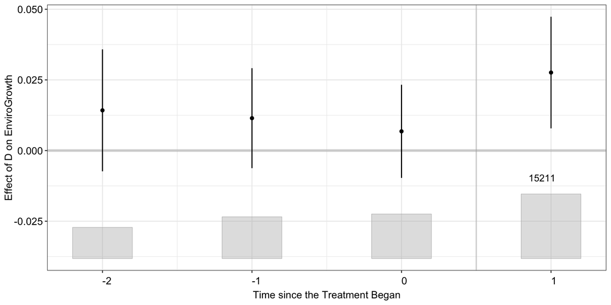

## Results II

Preference for the `Greens`:

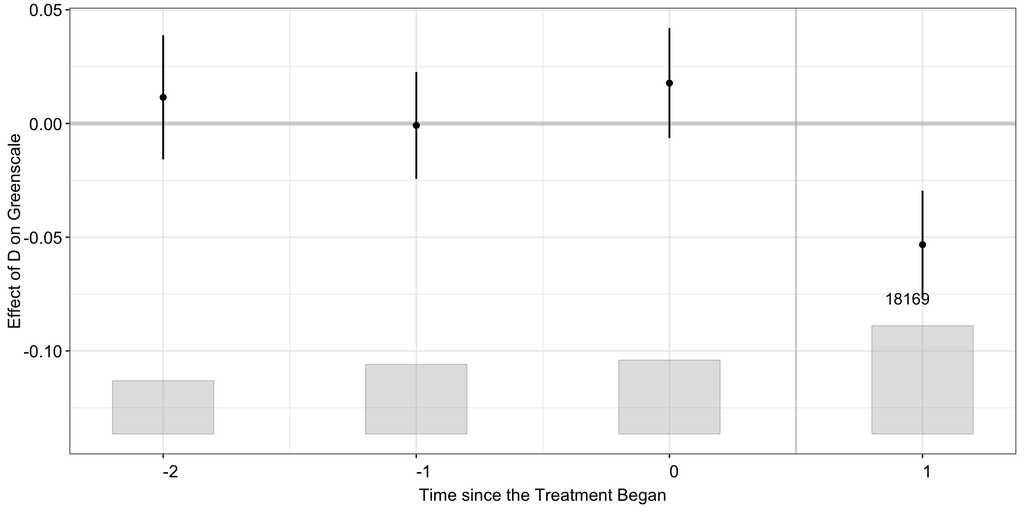

# Exploiting an exogenous shock for causal identification

## Data & Design I

- abrupt consumer price increases after `Russia's attack on Ukraine`
- `assumption`: prices hit low income households immediately, affluent households are more insulated
  - 2020 GLES extension, `N = 11,600`
  - `treatment`: up to 60% of median household income
  - `control`: above 150% of median household income
- `difference-in-differences` design

## Data & Design I

Harmonized Index of Consumer Prices (`HICP`) for Germany:

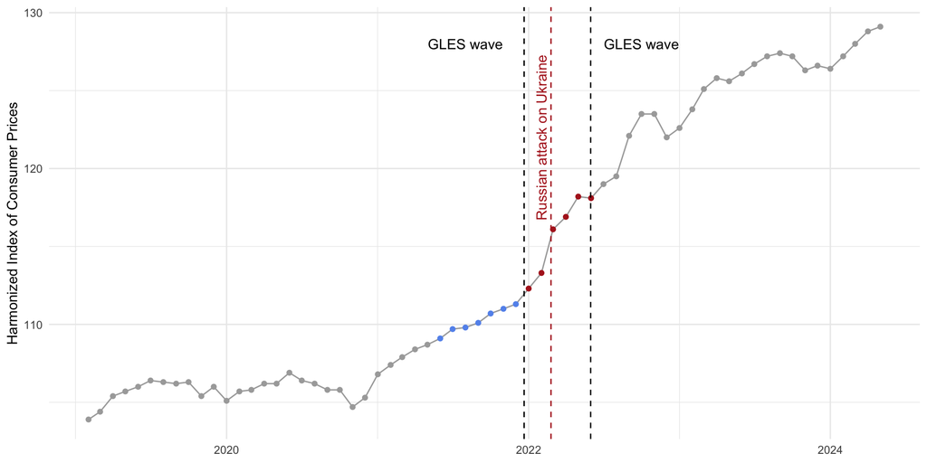

## Assessing parallel trends I

Group-means and *DiD-counterfactual* for `trade-off outcome`:

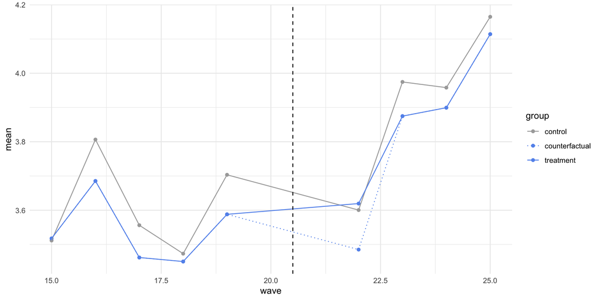

## Assessing parallel trends II

Group-means and *DiD-counterfactual* for `Greens outcome`:

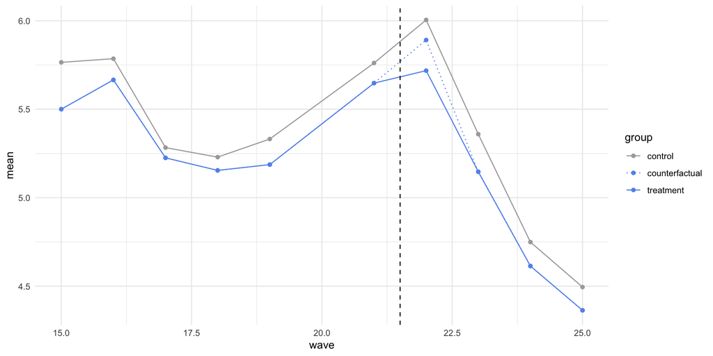

## Results I

`Effect on trade-off`:

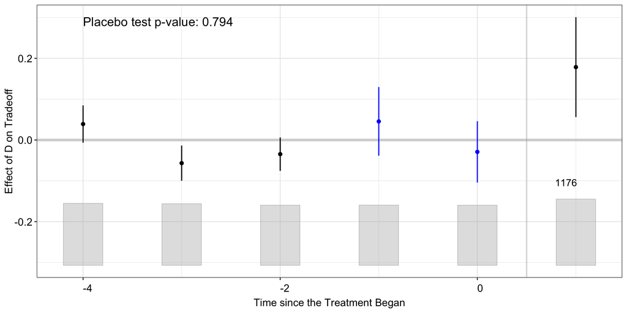

## Results II

`Effect on preference for the Greens`:

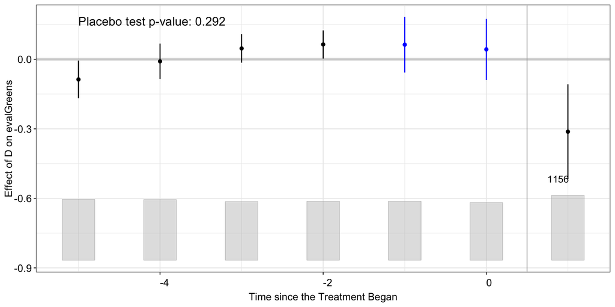

# Discussion

- personal economic decline indeed leads to **prioritization of economic growth** over climate protection
- accompanied by **decreased preference for the Greens**
- `implications`:
  - *policy making*: buffer `social impacts of green policies`
  - *electoral competition*: Greens as `niche`

# Thank you for your attention.

Questions or feedback? Hit me up:

- 🌐 [frederikthieme.net](https://frederikthieme.net/)
- 📥 frederik.thieme@hu-berlin.de
- 🟦 frederikthieme.bsky.social
- 🐦 frederik_thieme

# Literature

Abou-Chadi, Tarik, and Mark A. Kayser. 2017. “It’s Not Easy Being Green: Why Voters Punish Parties for Environmental Policies During Economic Downturns.” *Electoral Studies* 45 (February): 201–7. https://doi.org/10.1016/j.electstud.2016.10.009.

Andre, Peter, Teodora Boneva, Felix Chopra, and Armin Falk. 2024. “Globally Representative Evidence on the Actual and Perceived Support for Climate Action.” *Nature Climate Change*, February. https://doi.org/10.1038/s41558-024-01925-3.

Gourley, Patrick, and Melanie Khamis. 2023. “It Is Not Easy Being a Green Party: Green Politics as a Normal Good.” *European Journal of Political Economy* 76 (January): 102266. https://doi.org/10.1016/j.ejpoleco.2022.102266.

Inglehart, Ronald. 1971. “The Silent Revolution in Europe: Intergenerational Change in Post-Industrial Societies.” *American Political Science Review* 65 (4): 991–1017. https://doi.org/10.2307/1953494.

———. 2008. “Changing Values Among Western Publics from 1970 to 2006.” *West European Politics* 31 (1): 130–46. https://doi.org/10.1080/01402380701834747.

Kurer, Thomas, and Briitta Van Staalduinen. 2022. “Disappointed Expectations: Downward Mobility and Electoral Change.” *American Political Science Review* 116 (4): 1340–56. https://doi.org/10.1017/S0003055422000077.

Rudolph, Lukas, and Sarah Gomm. 2024. “How Does an Economic Shock Affect Environmental Attitudes, Preferences and Issue Importance? Evidence from Switzerland.” *Climatic Change* 177 (4): 63. https://doi.org/10.1007/s10584-024-03709-2.

Schaub, Max. 2021. “Acute Financial Hardship and Voter Turnout: Theory and Evidence from the Sequence of Bank Working Days.” *American Political Science Review* 115 (4): 1258–74. https://doi.org/10.1017/S0003055421000551.